# Obesity: demographic and life style

Gal Levin

5/15/2021

**For data cleaning and preparation for analysis,** please see the previous file, “The data”.

# Demographics

In this file we look at the spread of obesity within different demographic stratifications.

## Gender and the prevalence of obesity

Does the rate of obesity depend on gender? (Gender is binary in this dataset.)

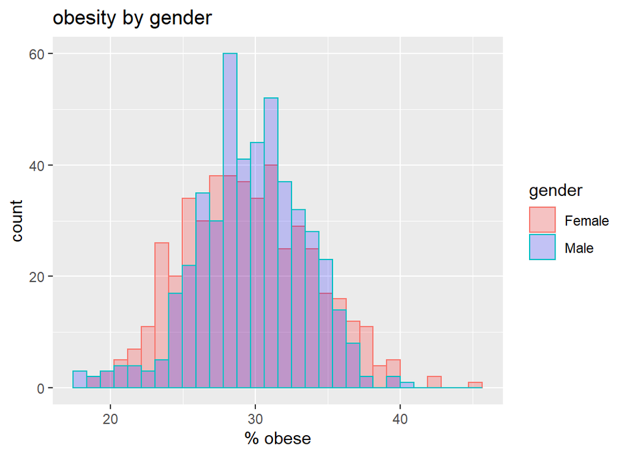

```r
# Extracting the data:
gender<-obesity_final%>%
  filter(Question=='Percent of adults aged 18 years and older who have obesity')%>%
  filter(StratificationCategory1=="Gender")%>%
  rename(gender = Stratification1)

# Histogram:
ggplot(gender, aes(x =Data_Value))+
  geom_histogram(aes(color = gender, fill = gender),
                 alpha = 0.2, position = "identity") +
  scale_fill_manual(values = c("red", "blue"))+
  ylab("count")+
  xlab("% obese")+
  ggtitle ("obesity by gender")
```

Values derived from both genders peak around the same values, though the histogram for males is “thinner”; there are less sub-populations of men with very low or with very high rates of obesity than of women.

As for statistical significance: Let’s separate the data set by genders:

```r
female<-gender%>%
  filter(gender == "Female")

male<-gender%>%
  filter(gender == "Male")
```

Common statistical tests to determine whether two populations are significantly different from each other are the z and the t tests. However, normal distribution is one of the underline assumptions behind both tests. Are our populations normally distributed?

```r
shapiro.test(female$Data_Value)
```

```
##
##  Shapiro-Wilk normality test
##
## data:  female$Data_Value
## W = 0.9937, p-value = 0.04686
```

```r
shapiro.test(male$Data_Value)
```

```
##
##  Shapiro-Wilk normality test
##
## data:  male$Data_Value
## W = 0.9902, p-value = 0.003123
```

They are not. Kruskal-Wallis test, however, does not require a normal distribution and can be used instead:

```r
kruskal.test(Data_Value ~ gender, data = gender)
```

```
##
##  Kruskal-Wallis rank sum test
##
## data:  Data_Value by gender
## Kruskal-Wallis chi-squared = 2.4165, df = 1, p-value = 0.1201
```

Judged by this test, the prevalence of obesity is not significantly different between the two genders.

## Age and the prevalence of obesity

Does the likelihood of being obese change with age?

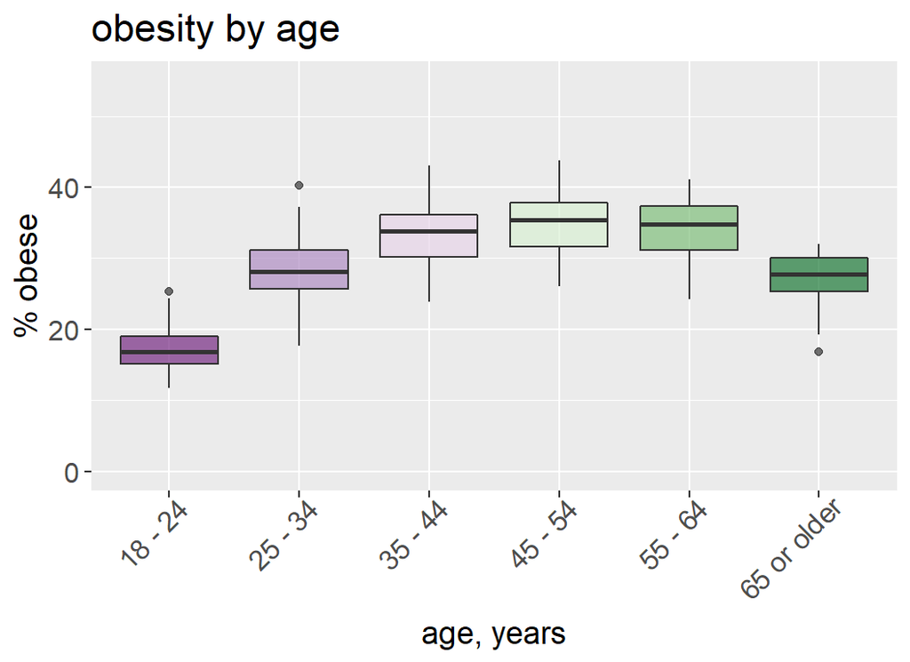

```r
# Extracting the data:
age <-obesity_final%>%
  filter(Question=='Percent of adults aged 18 years and older who have obesity')%>%
  filter(StratificationCategory1=='Age (years)')%>%
  group_by(LocationDesc, Stratification1)%>%
  summarise(average=mean(Data_Value))

# Box plot:
ggplot(age, aes(x=Stratification1, y=average, fill=Stratification1))+
  scale_fill_brewer(palette="PRGn")+
  geom_boxplot(trim=FALSE, alpha=0.7)+
  ylab("% obese")+
  xlab("age, years")+
  ggtitle ("obesity by age")+
  theme(legend.position="none",
        text = element_text(size = 14),
        axis.text.x=element_text(size=12,
                                 angle=45, hjust = 0.9),
        axis.text.y = element_text(size = 12))+
  ylim(0,55)
```

We see that there is an increase in the rate of obesity with age, reaching plateau at mid-age, then a decrease in the older age group.

Is the effect of age statistically significant? In order to decide which statistical test to use to answer this, let’s check whether our samples are normally distributed:

```r
age_groups<-unique(age$Stratification1)

for (grp in seq_along(age_groups)) {
  a<-age%>%
    filter(Stratification1==age_groups[grp])
  cat(paste("age group", age_groups[grp], ":", "\n"))
  print(shapiro.test(a$average)[2])
}
```

```
## age group 18 - 24 :
## $p.value
## [1] 0.08293904
##
## age group 25 - 34 :
## $p.value
## [1] 0.953344
##
## age group 35 - 44 :
## $p.value
## [1] 0.7425719
##
## age group 45 - 54 :
## $p.value
## [1] 0.8114854
##
## age group 55 - 64 :
## $p.value
## [1] 0.0695943
##
## age group 65 or older :
## $p.value
## [1] 0.004823011
```

Since some of the data groups are not normally distributed, statistical tests that do not require normal distribution are used:

```r
kruskal.test(average ~ Stratification1, data = age)
```

```
##
##  Kruskal-Wallis rank sum test
##
## data:  average by Stratification1
## Kruskal-Wallis chi-squared = 209.15, df = 5, p-value < 2.2e-16
```

Age effect is statistically significant.

Which age groups are different from which?

```r
pairwise.wilcox.test(age$average, age$Stratification1,
                     p.adjust.method = "BH")
```

```
##
##  Pairwise comparisons using Wilcoxon rank sum test with continuity correction
##
## data:  age$average and age$Stratification1
##
##             18 - 24 25 - 34 35 - 44 45 - 54 55 - 64
## 25 - 34     < 2e-16 -       -       -       -
## 35 - 44     < 2e-16 3.3e-07 -       -       -
## 45 - 54     < 2e-16 3.8e-11 0.05    -       -
## 55 - 64     < 2e-16 9.3e-10 0.27    0.34    -
## 65 or older < 2e-16 0.28    2.0e-10 6.4e-15 1.5e-13
##
## P value adjustment method: BH
```

We see that the increase in the rate of obesity from youth to mid age is statistically significant. Also significant is the decrease in the prevalence in the older age group; it is now statistically indistinguishable from the that of young adults (25 - 24 years old).

Two different types of explanations might be behind this trend:

1. Reasons that are tied to age itself. A hypothetical example for such an explanation would be that appetite wanes in age and people eat less. Another hypothetical explanation, a grim one, is that obese people are less likely to live to old age.
2. Reasons stating a cohort effect: those who were born on the 40s are different than those who were born in the 90s, be is culturally or biologically (for example, they might have been exposed to different environmental pollutant at youth that created epi-genetic change).

The two types of root causes would lead to different predictions regarding future prevalence of obesity. Reasons tied to age itself would predict that the increase, then decrease in the prevalence of obesity will continue in the future. Cohort-effect reasons would predict that relatively thin population would keep being thin as they age, and likewise, cohorts with high obesity rate will continue being so. Such predictions are important for people in the public health area, trying to form policies and allocate resources for the future. It is also important for business developers, trying to plan for future markets. So, which one it is?

While this data does not provide a clear answer, it does provide a suggestion. This is because the data were collected during about a decade. During that time, each cohort (almost) moved to the next cohort: those who were in their twenties when the project took off are now in their thirties, those who were in their thirties are now in their forties. etc. We can plot the data for each year and see whether they all look similar - that would point to an age-related explanation, or are changing, which would point to cohort differences.

Here are the plots:

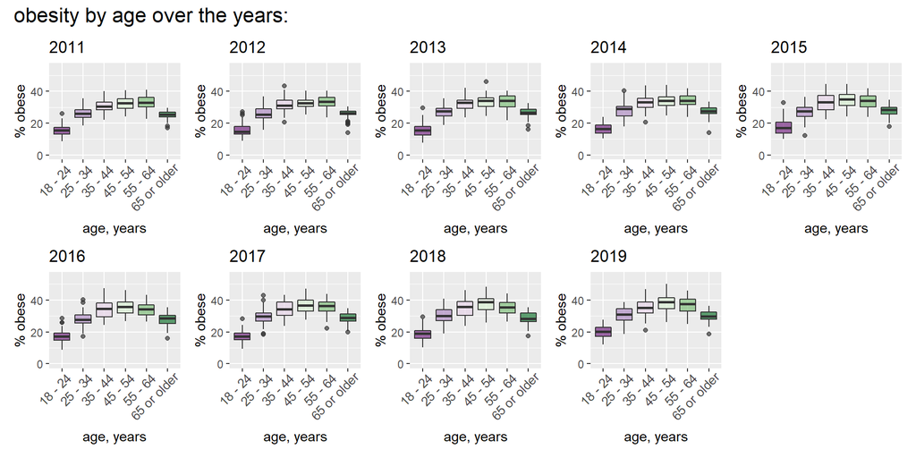

```r
# Extracting the data:
age <-obesity_final%>%
  filter(Question=='Percent of adults aged 18 years and older who have obesity')%>%
  filter(StratificationCategory1=='Age (years)')

# Creating a list to store the plots:
List <- list()

# The survey years:
age_year<-sort(unique(age$YearEnd))

# Looping over the years and creating a plot for each:
for (yir in seq_along(age_year)) {
  age_plot <- age%>%
    filter (YearEnd==age_year[yir])%>%
    ggplot(aes(x=Stratification1, y=Data_Value, fill=Stratification1))+
    scale_fill_brewer(palette="PRGn")+
    geom_boxplot(alpha=0.7)+
    ylab("% obese")+
    xlab("age, years")+
    theme(legend.position="none",
          axis.text.x=element_text(size=10,
                                   angle=45, hjust = 0.9))+
    ggtitle (age_year[yir])+
    ylim(0,55)

  List[[yir]]<-age_plot}

# Wrapping plots:
wp<-wrap_plots(List,nrow = 2)
wp + plot_annotation(
  title = "obesity by age over the years:", theme = theme(plot.title = element_text(size = 16)))
```

Similar patterns are seen over the years, pointing to explanations related to age itself.

## Race and the prevalence of obesity

Does obesity rate vary between different races / ethnicities?

```r
# Extracting the data:
race<-obesity_final%>%
  filter(Question=='Percent of adults aged 18 years and older who have obesity')%>%
  filter(StratificationCategory1=='Race/Ethnicity')

# Ordering the races / ethnicities by obesity rate, to ease visualization.
race%>%
  group_by(Stratification1) %>%
  summarise(number=n(), average=mean(Data_Value), sd=sd(Data_Value))%>%
  arrange(average)
```

```
## # A tibble: 8 x 4
##   Stratification1               number average    sd
##   <chr>                          <int>   <dbl> <dbl>
## 1 Asian                            303    10.5  4.78
## 2 Other                            146    26.5  7.30
## 3 Non-Hispanic White               465    28.1  4.64
## 4 Hispanic                         458    31.2  5.47
## 5 2 or more races                  431    31.7  7.23
## 6 American Indian/Alaska Native    316    36.6  8.81
## 7 Non-Hispanic Black               376    37.7  5.50
## 8 Hawaiian/Pacific Islander         24    41.0 11.1
```

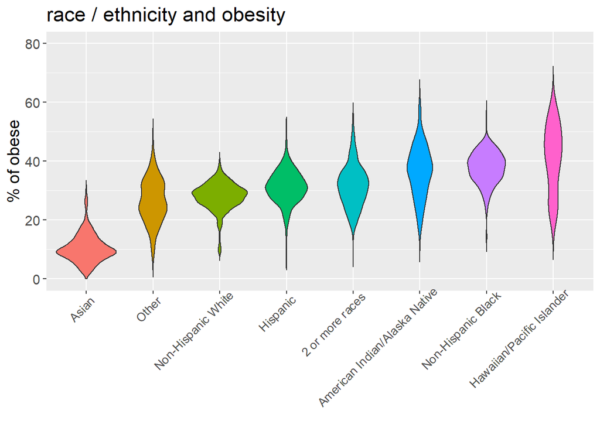

```r
dif_race<-c("Asian", "Other", "Non-Hispanic White",
            "Hispanic", "2 or more races",
            "American Indian/Alaska Native",
            "Non-Hispanic Black",
            "Hawaiian/Pacific Islander")

# The plot:
obesity_final%>%
  filter(Question=='Percent of adults aged 18 years and older who have obesity')%>%
  filter(StratificationCategory1=='Race/Ethnicity')%>%
  arrange(Stratification1) %>%
  mutate(Stratification1=factor(Stratification1, levels = dif_race))%>%
  ggplot(aes(x=Stratification1, y=Data_Value, fill=Stratification1))+
  geom_violin(trim=FALSE)+
  ylab("% of obese")+
  ggtitle ("race / ethnicity and obesity")+
  theme(legend.position="none",
        text = element_text(size = 14),
        axis.text.x=element_text(size=10,
                                 angle=45, hjust = 0.9),
        axis.title.x = element_blank())+
  ylim(0,80)
```

The use of violin plot demonstrates nicely that not all the populations are homogenous: some ethnicity groups are composed of more than one cluster of data, each distributed around its own median.

Are the differences statistically significant?

Checking data for normal distribution:

```r
race_groups<-unique(race$Stratification1)

for (grp in seq_along(race_groups)) {
  a<-race%>%
    filter(Stratification1==race_groups[grp])
  cat(paste(race_groups[grp], "ethnicity group:",":\n"))
  print(shapiro.test(a$Data_Value)[2])
}
```

```
## 2 or more races ethnicity group: :
## $p.value
## [1] 0.004906485
##
## American Indian/Alaska Native ethnicity group: :
## $p.value
## [1] 0.2794757
##
## Hispanic ethnicity group: :
## $p.value
## [1] 0.007180058
##
## Non-Hispanic Black ethnicity group: :
## $p.value
## [1] 3.161999e-05
##
## Non-Hispanic White ethnicity group: :
## $p.value
## [1] 9.751593e-13
##
## Other ethnicity group: :
## $p.value
## [1] 0.8309195
##
## Asian ethnicity group: :
## $p.value
## [1] 8.5549e-10
##
## Hawaiian/Pacific Islander ethnicity group: :
## $p.value
## [1] 0.07002833
```

Since some of the groups are not normally distributed, statistical tests are used that do not require normal distribution:

```r
kruskal.test(Data_Value ~ Stratification1, data = race)
```

```
##
##  Kruskal-Wallis rank sum test
##
## data:  Data_Value by Stratification1
## Kruskal-Wallis chi-squared = 1244.8, df = 7, p-value < 2.2e-16
```

The differences are statistically significant.

Which race groups are different from which?

```r
pairwise.wilcox.test(race$Data_Value, race$Stratification1,
                     p.adjust.method = "BH")
```

```
##
##  Pairwise comparisons using Wilcoxon rank sum test with continuity correction
##
## data:  race$Data_Value and race$Stratification1
##
##                               2 or more races American Indian/Alaska Native
## American Indian/Alaska Native 5.8e-16         -
## Asian                         < 2e-16         < 2e-16
## Hawaiian/Pacific Islander     4.6e-05         0.0303
## Hispanic                      0.6534          < 2e-16
## Non-Hispanic Black            < 2e-16         0.0606
## Non-Hispanic White            1.4e-15         < 2e-16
## Other                         1.2e-11         < 2e-16
##                               Asian   Hawaiian/Pacific Islander Hispanic
## American Indian/Alaska Native -       -                         -
## Asian                         -       -                         -
## Hawaiian/Pacific Islander     1.2e-15 -                         -
## Hispanic                      < 2e-16 1.7e-05                   -
## Non-Hispanic Black            < 2e-16 0.0326                    < 2e-16
## Non-Hispanic White            < 2e-16 3.5e-07                   < 2e-16
## Other                         < 2e-16 9.1e-08                   8.1e-13
##                               Non-Hispanic Black Non-Hispanic White
## American Indian/Alaska Native -                  -
## Asian                         -                  -
## Hawaiian/Pacific Islander     -                  -
## Hispanic                      -                  -
## Non-Hispanic Black            -                  -
## Non-Hispanic White            < 2e-16            -
## Other                         < 2e-16            0.0044
##
## P value adjustment method: BH
```

## Year of survey and the prevalence of obesity: changes over time

Is there a time trend in the prevalence of obesity?

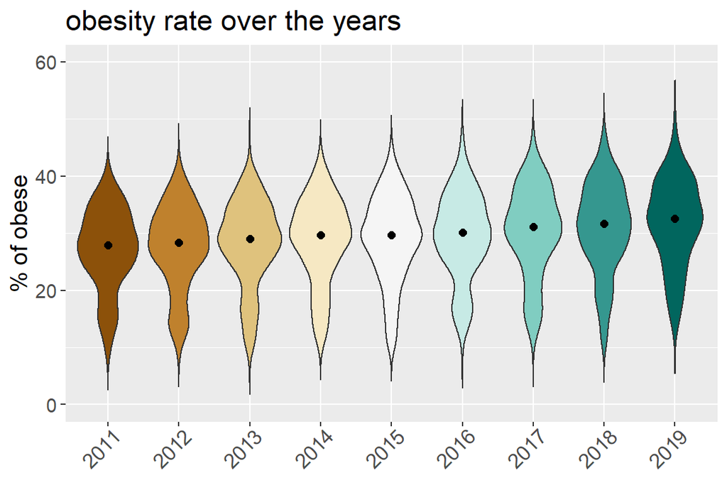

```r
# Extracting the data:
over_years <- obesity_final%>%
  filter(Question=='Percent of adults aged 18 years and older who have obesity')%>%
# In order to include each participant only once, only one stratification category is chosen.
  filter(StratificationCategory1=='Age (years)')

# Presenting the data in a violin plot:
over_years%>%
  arrange(YearEnd) %>%
  mutate(YearEnd=factor(YearEnd, levels = unique(YearEnd)))%>%
  ggplot(aes(x=YearEnd, y=Data_Value, fill=YearEnd))+
  scale_fill_brewer(palette="BrBG")+
  geom_violin(trim=FALSE)+
  stat_summary(fun.y=median, geom="point", size=2, color="black")+
  ylab("% of obese")+
  ggtitle ("obesity rate over the years")+
  theme(legend.position="none",
        text = element_text(size = 14),
        axis.text.x=element_text(size=12,
                                 angle=45, hjust = 0.9),
        axis.title.x = element_blank())+
  ylim(0,60)+
  ggtitle ("obesity rate over the years")
```

The black dot within the violins bars mark the median of the respective sample. Following the medians over years, we see that obesity level increases over the years.

Is the trend statistically significant?

First, checking if the data samples are of normal distribution:

```r
years<-unique(over_years$YearEnd)

for (yr in seq_along(years)) {
  a<-over_years%>%
    filter(YearEnd==years[yr])
  cat(paste("the year of ", years[yr], ":","\n"))
  print(shapiro.test(a$Data_Value)[2])
}
```

```
## the year of  2011 :
## $p.value
## [1] 1.070303e-05
##
## the year of  2012 :
## $p.value
## [1] 2.204016e-06
##
## the year of  2013 :
## $p.value
## [1] 9.363249e-07
##
## the year of  2014 :
## $p.value
## [1] 9.30658e-07
##
## the year of  2015 :
## $p.value
## [1] 2.160089e-05
##
## the year of  2016 :
## $p.value
## [1] 0.0002227653
##
## the year of  2017 :
## $p.value
## [1] 5.918955e-06
##
## the year of  2018 :
## $p.value
## [1] 0.0001410663
##
## the year of  2019 :
## $p.value
## [1] 0.000948402
```

They are not; Kruskal_Wallis test it is!

```r
kruskal.test(Data_Value ~ YearEnd, data = over_years)
```

```
##
##  Kruskal-Wallis rank sum test
##
## data:  Data_Value by YearEnd
## Kruskal-Wallis chi-squared = 106.01, df = 8, p-value < 2.2e-16
```

Highly significant differences. And which year is different from which?

```r
pairwise.wilcox.test(over_years$Data_Value, over_years$YearEnd,
                     p.adjust.method = "BH")
```

```
##
##  Pairwise comparisons using Wilcoxon rank sum test with continuity correction
##
## data:  over_years$Data_Value and over_years$YearEnd
##
##      2011    2012    2013    2014    2015    2016    2017    2018
## 2012 0.41094 -       -       -       -       -       -       -
## 2013 0.05310 0.29431 -       -       -       -       -       -
## 2014 0.00379 0.04155 0.31742 -       -       -       -       -
## 2015 0.00218 0.02889 0.25638 0.79666 -       -       -       -
## 2016 0.00022 0.00368 0.05310 0.35584 0.45682 -       -       -
## 2017 2.7e-07 1.2e-05 0.00063 0.01484 0.02872 0.13098 -       -
## 2018 2.0e-09 1.4e-07 1.7e-05 0.00073 0.00204 0.01484 0.36396 -
## 2019 2.5e-12 2.5e-10 7.7e-08 6.0e-06 2.0e-05 0.00037 0.03942 0.27607
##
## P value adjustment method: BH
```

It looks as if the change is very gradual. Obesity rate does not look much different from one year to the next, but the over a longer time span, the certainty that obesity rate increases, reflected in decrease of the p-value, becomes higher.

## Area of residency and the prevalence of obesity

Do states / territories vary in prevalence of obesity?

```r
# Extracting the data:
residency <-obesity_final%>%
  filter(Question=='Percent of adults aged 18 years and older who have obesity')%>%

# Filtering to only one stratification, so that each person is counted only once.
  filter(StratificationCategory1=='Age (years)')%>%
  group_by(LocationDesc)

res_sum<-residency%>%
  summarise(average=mean(Data_Value))%>%
  arrange(average)

as.data.frame(res_sum)
```

```
##            LocationDesc  average
## 1              Colorado 21.30370
## 2                Hawaii 23.23704
## 3  District of Columbia 23.55741
## 4         Massachusetts 23.61111
## 5            California 24.48704
## 6               Montana 25.08148
## 7            New Jersey 25.14792
## 8              New York 25.20556
## 9               Vermont 25.45185
## 10          Connecticut 25.64074
## 11                 Utah 25.97593
## 12               Nevada 26.41481
## 13              Florida 26.67222
## 14            Minnesota 26.90556
```

[output cut: 40 more lines]

Different states have different rates of obesity, but is the difference statistically significant? Turns out it is, whether you test is with ANOVA or with Kruskal-Wallis test.

```r
residency_anova <- aov(Data_Value ~ LocationDesc, data = residency)
summary(residency_anova)
```

```
##                Df Sum Sq Mean Sq F value Pr(>F)
## LocationDesc   53  33552   633.1   13.39 <2e-16 ***
## Residuals    2778 131292    47.3
## ---
## Signif. codes:  0 '***' 0.001 '**' 0.01 '*' 0.05 '.' 0.1 ' ' 1
```

```r
kruskal.test(Data_Value ~ LocationDesc, data = residency)
```

```
##
##  Kruskal-Wallis rank sum test
##
## data:  Data_Value by LocationDesc
## Kruskal-Wallis chi-squared = 636.64, df = 53, p-value < 2.2e-16
```

One can speculate numerous reasons for this association between state residency and obesity. It could be a result of different lifestyle, whether because of local culture or local circumstances. It could reflect homophilia - wanting to be among people like us. It could also result from environmental risk / protection factors. A very plausible explanation, though, is that local obesity level reflects the composition of the local population, with respect to race / ethnicity and age, as we saw above, and likely other factors as well.

Checking which state’s obesity prevalence is significantly different from which would be rather tedious. However, a related question of interest is whether the difference is not merely between states, but also between regions within the United States. Below I separate the states to regions following Wikipedia, with the justification, quote: “Many regions are defined in law or regulations by the federal government; others by shared culture and history; and others by economic factors.”

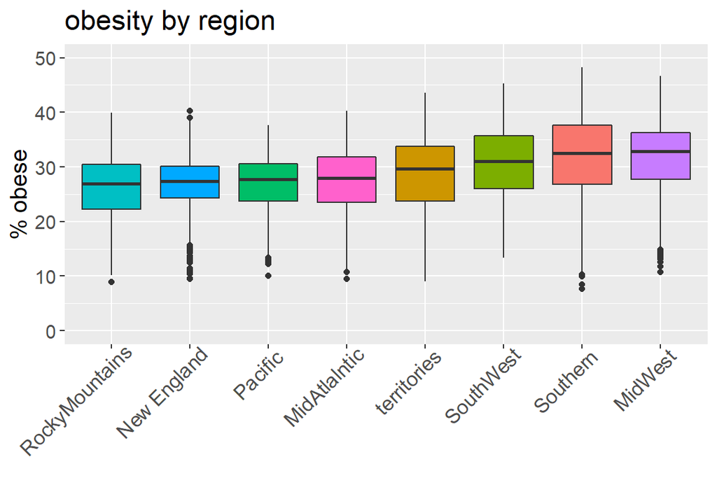

```r
# Grouping the locations into regions:
residency_region<-residency%>%
  mutate(region = case_when(LocationDesc %in% c("Maine", "Rhode Island", "Vermont", "Connecticut", "New Hampshire", "Massachusetts") ~ "New England",
                            LocationDesc %in% c("New York", "New Jersey", "Pennsylvania") ~ "MidAtlalntic",
                            LocationDesc %in% c("Virginia", "West Virginia", "Kentucky", "Delaware", "Maryland",
                                                "District of Columbia", "North Carolina", "South Carolina", "Tennessee", "Arkansas", "Louisiana", "Florida",
                                                "Georgia", "Alabama", "Mississippi") ~ "Southern",
                            LocationDesc %in% c("michigan", "North Dakota", "South Dakota", "Iowa", "Minnisota",
                                                "Kansas", "Nebraska", "Ohio", "Indiana", "Illinois", "Wisconsin", "Missouri") ~ "MidWest",
                            LocationDesc %in% c("Texas", "Arizona", "New Mexico", "Oklahoma") ~ "SouthWest",
                            LocationDesc %in% c("Montana", "Idaho", "Colorado", "Utah", "Wyoming", "Nevada") ~ "RockyMountains",
                            LocationDesc %in% c("California", "Oregon", "Washington") ~ "Pacific",
                            TRUE ~ "territories"))

# The plot:
residency_region%>%
  mutate(region=factor(region, levels=unique(region)))%>%
  ggplot(aes(x=reorder(region, Data_Value, FUN = median),region, y=Data_Value, fill=region))+
  geom_boxplot() +
  ylab("% obese")+
  xlab("age, years")+
  theme(legend.position="none",
        axis.title.x=element_blank(),
        axis.text.x=element_text(size=12,
                                 angle=45, hjust = 0.9))+
  ggtitle ("obesity by region")+
  theme(text = element_text(size = 14))+
  ylim(0,50)
```

And as for the statistical significance of the difference between regions: checking first for a normal distribution:

```r
dif_regions<-unique(residency_region$region)

for (rgn in seq_along(dif_regions)) {
  a<-residency_region%>%
    filter(region==dif_regions[rgn])
  cat(paste(dif_regions[rgn], ":","\n"))
  print(shapiro.test(a$Data_Value)[2])
}
```

```
## Southern :
## $p.value
## [1] 3.786372e-10
##
## territories :
## $p.value
## [1] 4.666181e-05
##
## SouthWest :
## $p.value
## [1] 0.0005639362
##
## Pacific :
## $p.value
## [1] 4.950148e-08
##
## RockyMountains :
## $p.value
## [1] 3.036544e-08
##
## New England :
## $p.value
## [1] 6.489717e-12
##
## MidWest :
## $p.value
## [1] 2.305969e-15
##
## MidAtlalntic :
## $p.value
## [1] 2.798374e-06
```

Again, we have samples that are not of normal distribution and the Kruskal-Wallis / Wilcoxon Rank Sum tests will be applied:

```r
kruskal.test(Data_Value ~ region, data = residency_region)
```

```
##
##  Kruskal-Wallis rank sum test
##
## data:  Data_Value by region
## Kruskal-Wallis chi-squared = 325.52, df = 7, p-value < 2.2e-16
```

Highly significant differences. And who is different than whom?

```r
pairwise.wilcox.test(residency_region$Data_Value, residency_region$region,
                     p.adjust.method = "BH")
```

```
##
##  Pairwise comparisons using Wilcoxon rank sum test with continuity correction
##
## data:  residency_region$Data_Value and residency_region$region
##
##                MidAtlalntic MidWest New England Pacific RockyMountains Southern
## MidWest        2.4e-13      -       -           -       -              -
## New England    0.2460       < 2e-16 -           -       -              -
## Pacific        0.4977       < 2e-16 0.6276      -       -              -
## RockyMountains 0.0813       < 2e-16 0.3376      0.2460  -              -
## Southern       1.0e-12      0.3455  < 2e-16     8.1e-16 < 2e-16        -
## SouthWest      7.3e-07      0.1606  3.2e-13     6.5e-09 5.9e-14        0.0592
## territories    0.0167       8.0e-08 1.6e-05     0.0015  1.5e-06        6.5e-09
##                SouthWest
## MidWest        -
## New England    -
## Pacific        -
## RockyMountains -
## Southern       -
## SouthWest      -
## territories    0.0029
##
## P value adjustment method: BH
```

We see that there are four regions with low obesity rate that is statistically identical: Rocky Mountain, New England, Pacific, and Mid Atlantic. On the higher obesity rate, Southwestern, Southern, and the MidWestern regions are statistically the same.

## Education and the prevalence of obesity

Is obesity associated with level of education?

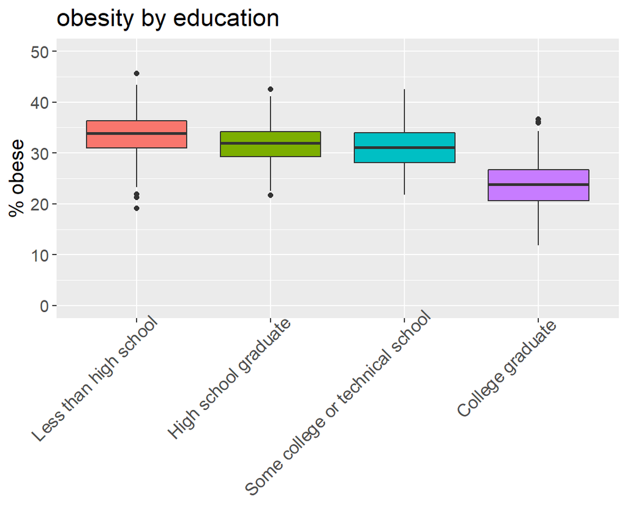

```r
# Extracting the data:
education <-obesity_final%>%
  filter(Question=='Percent of adults aged 18 years and older who have obesity')%>%
  filter(StratificationCategory1=='Education')

# Visualization - box plot:
education%>%
  arrange(Stratification1)%>%
  mutate(Stratification1 = factor(Stratification1, levels=c("Less than high school", "High school graduate", "Some college or technical school", "College graduate")))%>%
  ggplot(aes(x=Stratification1, y=Data_Value, fill=Stratification1))+
  geom_boxplot()+
  ylab("% obese")+
  theme(legend.position="none",
        text = element_text(size = 14),
        axis.text.x=element_text(size=12,
                                 angle=45, hjust = 0.9),
        axis.title.x = element_blank())+
  ggtitle ("obesity by education")+
  ylim(0,50)
```

Obesity is less prevalent among the more educated. Quantitatively, the biggest difference is between college educated and all other lower level of education.

Checking statistical significance, starting with checking whether the data are of normal distribution:

```r
ed_levels<-unique(education$Stratification1)

for (lvl in seq_along(ed_levels)) {
  a<-education%>%
    filter(Stratification1==ed_levels[lvl])
  cat(paste("level of education: ", ed_levels[lvl], ":","\n"))
  print(shapiro.test(a$Data_Value)[2])
}
```

```
## level of education:  Less than high school :
## $p.value
## [1] 0.7236705
##
## level of education:  College graduate :
## $p.value
## [1] 0.7667469
##
## level of education:  Some college or technical school :
## $p.value
## [1] 0.03479082
##
## level of education:  High school graduate :
## $p.value
## [1] 0.5296348
```

One of the samples is not of normal distribution, we use the Kruskal-Wallis test:

```r
kruskal.test(Data_Value ~ Stratification1, data = education)
```

```
##
##  Kruskal-Wallis rank sum test
##
## data:  Data_Value by Stratification1
## Kruskal-Wallis chi-squared = 791.46, df = 3, p-value < 2.2e-16
```

Highly significant differences. And which level of education is different from which?

```r
pairwise.wilcox.test(education$Data_Value, education$Stratification1,
                     p.adjust.method = "BH")
```

```
##
##  Pairwise comparisons using Wilcoxon rank sum test with continuity correction
##
## data:  education$Data_Value and education$Stratification1
##
##                                  College graduate High school graduate
## High school graduate             <2e-16           -
## Less than high school            <2e-16           9e-13
## Some college or technical school <2e-16           0.0073
##                                  Less than high school
## High school graduate             -
## Less than high school            -
## Some college or technical school <2e-16
##
## P value adjustment method: BH
```

They are all different from each other.

Why would obesity rate go down as education goes up is not easy to explain. It could be that high education is associated with medical literacy that enable people to make better health decisions. I personally am not persuaded by this explanation, primarily because the knowledge of how to lose weight is very accessible in our society, not hidden in obscure libraries of some exclusive academic institutes. I suspect that this has to do with the cost and accessibility of education, where obese people are less advantageous, as can be seen below.

## Income and the prevalence of obesity

Is income level associated with obesity?

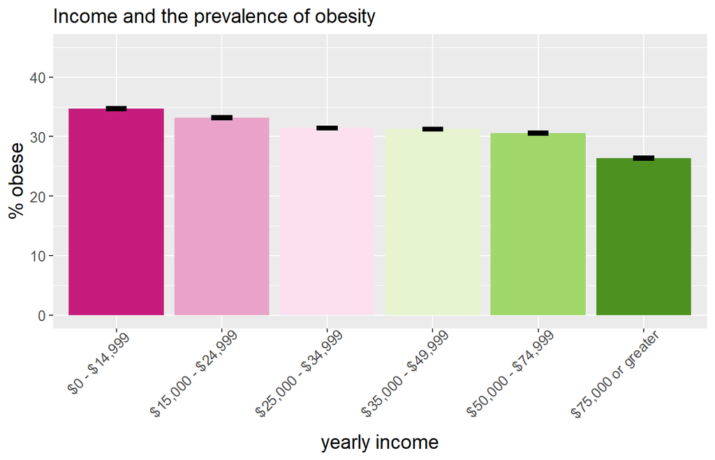

```r
# Extracting the data. Note, some participants did not report income; I opt not to include this category.
income <-obesity_final%>%
  filter(Question=='Percent of adults aged 18 years and older who have obesity')%>%
  filter(StratificationCategory1=='Income')%>%
  filter(!Stratification1=="Data not reported")

# To arrange the plot by order of income:
for (i in 1:(length(income$Stratification1)))
  if(income$Stratification1[i]== "Less than $15,000"){
    income$Stratification1[i]<-"$0 - $14,999"
  }

# The plot:
income%>%
  group_by(Stratification1)%>%
  summarise(number=n(), average=mean(Data_Value),
            sd=sd(Data_Value))%>%
  mutate(se=(sd/sqrt(number)))%>%
  ggplot(aes(x=Stratification1, y=average, fill=Stratification1))+
  geom_bar(stat="identity")+
  scale_fill_brewer(palette="PiYG")+
  geom_errorbar(aes(x= Stratification1, ymin=average-se, ymax=average+se), width=0.2, color="black", alpha=2, size=1)+
  ylab("% obese")+
  xlab("yearly income")+
  ggtitle ("Income and the prevalence of obesity")+
  theme(legend.position="none",
        axis.text.x=element_text(size=10,
                                 angle=45, hjust = 0.9),
        axis.text.y = element_text(size=10),
        plot.title = element_text(size = 14),
        axis.title = element_text(size = 14))+
  ylim(0,45)
```

Obesity is lower among those with higher income.

Are the differences significant?

Checking first whether the data is of normal distribution:

```r
income_levels<-unique(income$Stratification1)
for (inc in seq_along(income_levels)) {
  a<-income%>%
    filter(Stratification1==income_levels[inc])
  cat(paste("yearly income: ", income_levels[inc], ":","\n"))
  print(shapiro.test(a$Data_Value)[2])
}
```

```
## yearly income:  $25,000 - $34,999 :
## $p.value
## [1] 0.224635
##
## yearly income:  $50,000 - $74,999 :
## $p.value
## [1] 0.8721428
##
## yearly income:  $35,000 - $49,999 :
## $p.value
## [1] 0.764234
##
## yearly income:  $0 - $14,999 :
## $p.value
## [1] 0.4659222
##
## yearly income:  $75,000 or greater :
## $p.value
## [1] 0.06475006
##
## yearly income:  $15,000 - $24,999 :
## $p.value
## [1] 0.4429376
```

They are; ANOVA could be appropriate.

```r
income$Stratification1<-factor(income$Stratification1)
income_anova <- aov(Data_Value ~ Stratification1, data = income)
summary(income_anova)
```

```
##                   Df Sum Sq Mean Sq F value Pr(>F)
## Stratification1    5  18753    3751   185.2 <2e-16 ***
## Residuals       2826  57223      20
## ---
## Signif. codes:  0 '***' 0.001 '**' 0.01 '*' 0.05 '.' 0.1 ' ' 1
```

The difference is statistically significant. Which levels of income are different from each other?

```r
income_thsd<-TukeyHSD(income_anova, which = "Stratification1")
as.data.frame(income_thsd$Stratification1)
```

```
##                                            diff       lwr         upr
## $15,000 - $24,999-$0 - $14,999       -1.5012712 -2.336572 -0.66597063
## $25,000 - $34,999-$0 - $14,999       -3.2345339 -4.069834 -2.39923334
## $35,000 - $49,999-$0 - $14,999       -3.4072034 -4.242504 -2.57190283
## $50,000 - $74,999-$0 - $14,999       -4.1016949 -4.936995 -3.26639436
## $75,000 or greater-$0 - $14,999      -8.3040254 -9.139326 -7.46872487
## $25,000 - $34,999-$15,000 - $24,999  -1.7332627 -2.568563 -0.89796215
## $35,000 - $49,999-$15,000 - $24,999  -1.9059322 -2.741233 -1.07063165
## $50,000 - $74,999-$15,000 - $24,999  -2.6004237 -3.435724 -1.76512317
## $75,000 or greater-$15,000 - $24,999 -6.8027542 -7.638055 -5.96745368
## $35,000 - $49,999-$25,000 - $34,999  -0.1726695 -1.007970  0.66263107
## $50,000 - $74,999-$25,000 - $34,999  -0.8671610 -1.702462 -0.03186046
## $75,000 or greater-$25,000 - $34,999 -5.0694915 -5.904792 -4.23419097
## $50,000 - $74,999-$35,000 - $49,999  -0.6944915 -1.529792  0.14080903
## $75,000 or greater-$35,000 - $49,999 -4.8968220 -5.732123 -4.06152148
## $75,000 or greater-$50,000 - $74,999 -4.2023305 -5.037631 -3.36702995
##                                             p adj
## $15,000 - $24,999-$0 - $14,999       4.711805e-06
## $25,000 - $34,999-$0 - $14,999       0.000000e+00
## $35,000 - $49,999-$0 - $14,999       0.000000e+00
## $50,000 - $74,999-$0 - $14,999       0.000000e+00
## $75,000 or greater-$0 - $14,999      0.000000e+00
## $25,000 - $34,999-$15,000 - $24,999  5.354927e-08
## $35,000 - $49,999-$15,000 - $24,999  4.064971e-12
## $50,000 - $74,999-$15,000 - $24,999  0.000000e+00
## $75,000 or greater-$15,000 - $24,999 0.000000e+00
## $35,000 - $49,999-$25,000 - $34,999  9.917555e-01
## $50,000 - $74,999-$25,000 - $34,999  3.655585e-02
## $75,000 or greater-$25,000 - $34,999 0.000000e+00
## $50,000 - $74,999-$35,000 - $49,999  1.668393e-01
## $75,000 or greater-$35,000 - $49,999 0.000000e+00
## $75,000 or greater-$50,000 - $74,999 0.000000e+00
```

Not a very friendly presentation, but the general picture according to this test is, obesity level is rather statistically distinct for the different income levels.

Several reasons could be behind this association. It could be that people with more income can take better care of themselves, affording healthier food and leisure exercise. But the causality may be to the opposite direction: obese people face disadvantage in the hiring process and may be more likely to suffer co-morbidities that prevent them from keeping high-income positions. In addition, as suggested by the previous section, obese people are less likely to get higher education that could put them in a higher income bracket. Thus, education and income may intertwine when it comes to obesity: obese people tend to make less money, therefore are less likely to afford the education that would help them earn more.